# R Notebook

Octavio del Ser

10/11/2020

## Question 1

Testing for different values of h. Variable declaration:

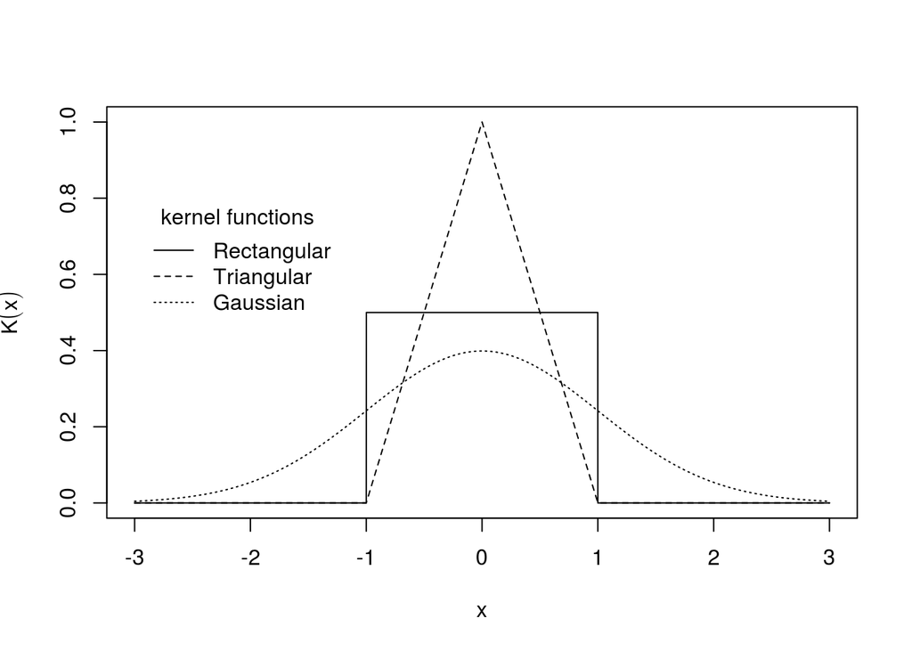

```r
rec <- function(x) (abs(x) < 1) * 0.5
tri <- function(x) (abs(x) < 1) * (1 - abs(x))
gauss <- function(x) 1 / sqrt(2 * pi) * exp(-(x^2) / 2)
x <- seq(from = -3, to = 3, by = 0.001)
plot(x, rec(x), type = "l", ylim = c(0, 1), lty = 1,
     ylab = expression(K(x)))
lines(x, tri(x), lty = 2)
lines(x, gauss(x), lty = 3)
legend(-3, 0.8, legend = c("Rectangular", "Triangular", "Gaussian"),
       lty = 1:3, title = "kernel functions", bty = "n")
```

```r
x <- c(0, 1, 1.1, 1.5, 1.9, 2.8, 2.9, 3.5)
n <- length(x)
xgrid <- seq(from = min(x) - 1, to = max(x) + 1, by = 0.01)
```

Testing different values: (h=0.1 -> 1 increments of .1

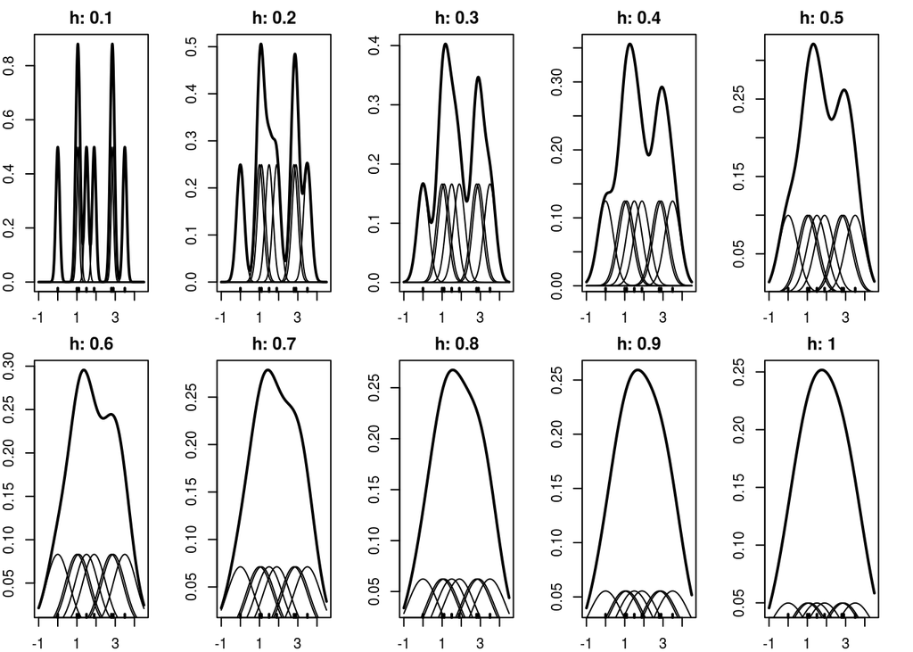

```r
par(mfrow = c(2, 5))
par(mar = c(2, 2, 2, 2))

h_vals <- seq(0.1, 1, by = 0.1)
for (h in h_vals) {
  bumps <- sapply(x, function(a) gauss((xgrid - a) / h) / (n * h))
  plot(xgrid, rowSums(bumps), ylab = expression(hat(f)(x)),
       type = "l", xlab = "x", lwd = 2, main = paste0('h: ', h))
  rug(x, lwd = 2)
  out <- apply(bumps, 2, function(b) lines(xgrid, b))
}
```

As seen above the h value defines the trade-off between bias and variance, we want to choose a value of h as small as the data will allow, this way keeping bias low and variance as high as the prediction will allow. we can see as h increases the cure becomes smoother meaning variance is reduced but bias is large.

## Question 2

### a)

Generate three sets of 20 observation with their respective mean shift (60 total). 50 variables.

```r
num_classes <- 3
variables <- 50
obs <- 20
set.seed(2394)
total_obs <- obs * num_classes
x <- matrix(rnorm(num_classes*variables*obs), ncol = variables)
mean_shift <- sample(-10:10, obs, replace = FALSE)
for (var in 1:variables) {
  for (c in 0:(num_classes - 1)) {
    l<-(c * obs):((c + 1) * obs)
    x[l, var] <- x[l, var]+ mean_shift[c+1]
  }
}
```

### b)

Perform k-means

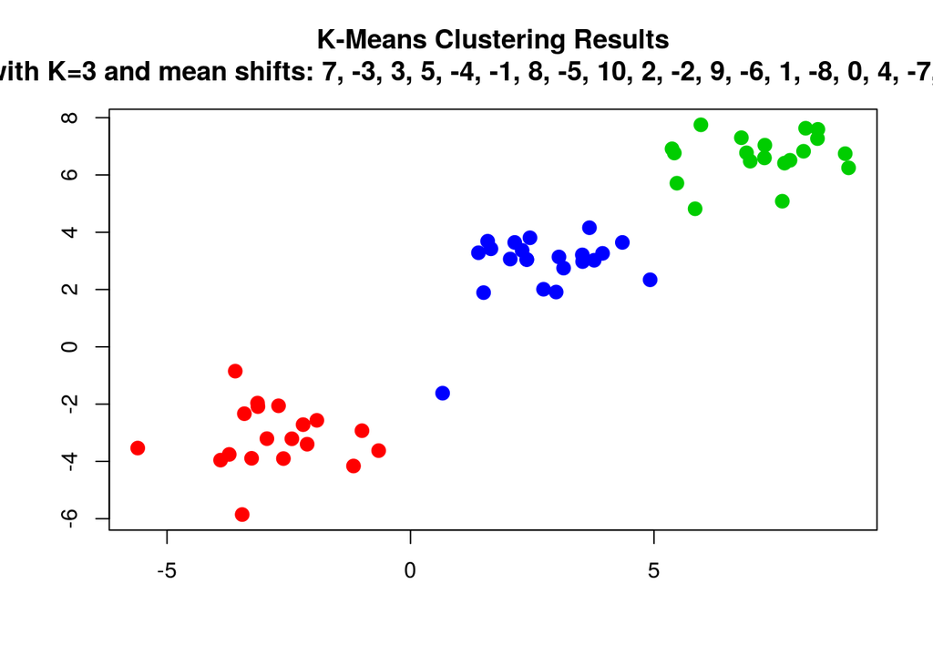

```r
km.out <- kmeans(x, 3, nstart = 20)
plot(x, col = (km.out$cluster + 1), main = paste0("K-Means Clustering Results
with K=", num_classes, ' and mean shifts: ', paste(mean_shift, collapse = ', ')), xlab = "", ylab = "", pch = 20, cex = 2)
```

```r
km.out
```

```
K-means clustering with 3 clusters of sizes 19, 19, 22

Cluster means:
       [,1]      [,2]      [,3]      [,4]      [,5]      [,6]      [,7]
1 -2.789662 -3.157444 -3.076738 -3.004841 -2.974478 -2.998164 -2.933273
2  7.220740  6.656530  7.033182  7.224075  7.241392  6.862484  6.991693
3  2.732834  2.866781  3.022151  2.913812  3.118246  2.952528  3.042120
       [,8]      [,9]     [,10]     [,11]     [,12]     [,13]     [,14]
1 -2.684439 -3.141446 -2.833779 -2.969685 -3.308639 -3.290958 -3.129807
2  6.997343  7.080045  7.256726  6.894027  7.122301  6.867840  6.835535
3  2.805182  2.968792  2.851196  2.781620  3.207810  3.152008  3.069462
      [,15]     [,16]     [,17]     [,18]     [,19]     [,20]     [,21]
1 -3.152811 -3.039077 -3.125203 -3.306515 -2.841006 -2.859442 -2.840322
2  7.162652  7.448180  7.173826  6.985566  6.979811  7.048311  6.858875
3  3.204855  2.721381  2.628888  2.792583  2.753956  2.589488  2.705047
      [,22]     [,23]     [,24]     [,25]     [,26]     [,27]     [,28]
1 -2.742864 -3.459537 -3.264991 -3.409272 -2.938646 -3.079583 -2.763221
2  7.528625  6.910193  7.126396  7.042081  6.631788  7.065006  6.885170
3  3.123315  2.949194  2.666261  3.059148  3.010498  2.676863  2.616278
      [,29]     [,30]     [,31]     [,32]     [,33]     [,34]     [,35]
1 -3.088382 -2.659546 -3.152875 -2.831973 -2.959039 -2.769228 -3.435983
2  6.883880  7.061039  6.851219  6.860330  6.763213  6.960692  6.768838
3  2.863755  3.230041  2.712202  3.362523  2.835991  3.296806  2.794797
      [,36]     [,37]     [,38]     [,39]     [,40]     [,41]     [,42]
1 -2.805715 -3.150647 -3.004114 -3.215667 -3.360708 -3.287220 -3.174931
2  6.893928  6.977747  7.427055  7.226921  6.928418  6.727538  7.039362
3  2.624308  2.926492  2.979969  3.254451  2.853778  3.094650  2.867790
      [,43]     [,44]     [,45]     [,46]     [,47]     [,48]     [,49]
1 -2.619662 -2.979423 -3.355402 -2.794699 -2.809716 -3.251691 -3.447609
2  6.752883  6.898152  7.118077  7.204324  6.958161  6.747656  7.303133
3  3.014976  2.633045  2.949298  2.628290  3.028873  2.701534  2.737831
      [,50]
1 -2.505418
2  7.044841
3  3.110570

Clustering vector:
 [1] 2 2 2 2 2 2 2 2 2 2 2 2 2 2 2 2 2 2 2 3 1 1 1 1 1 1 1 1 1 1 1 1 1 1 1 1 1 1
[39] 1 3 3 3 3 3 3 3 3 3 3 3 3 3 3 3 3 3 3 3 3 3

Within cluster sum of squares by cluster:
[1]  886.0936  888.5903 1519.3124
 (between_SS / total_SS =  93.7 %)

Available components:

[1] "cluster"      "centers"      "totss"        "withinss"     "tot.withinss"
[6] "betweenss"    "size"         "iter"         "ifault"
```

```r
km.out$tot.withinss
```

```
[1] 3293.996
```

### c)

k-means -> k=2

[figure not shown]

```r
km.out <- kmeans(x, 2, nstart = 20)
plot(x, col = (km.out$cluster + 1), main = paste0("K-Means Clustering Results
with K=", num_classes, ' and mean shifts: ', paste(mean_shift, collapse = ', ')), xlab = "", ylab = "", pch = 20, cex = 2)
```

```r
km.out
```

```
K-means clustering with 2 clusters of sizes 40, 20

Cluster means:
       [,1]      [,2]      [,3]      [,4]      [,5]      [,6]      [,7]
1  4.916437  4.779032  4.986895  5.004956  5.191897  4.837019  4.999154
2 -2.617233 -3.080472 -2.890801 -2.796446 -2.900154 -2.755153 -2.796478
       [,8]      [,9]     [,10]     [,11]     [,12]     [,13]     [,14]
1  4.861275  5.025888  4.972932  4.789647  5.157414  4.999219  4.940152
2 -2.539592 -3.044437 -2.607749 -2.791389 -3.163257 -3.133192 -2.983453
      [,15]     [,16]     [,17]     [,18]     [,19]     [,20]     [,21]
1  5.130588  5.047213  4.889167  4.860997  4.813056  4.786776  4.763954
2 -2.926486 -2.912260 -3.040365 -3.155054 -2.664896 -2.745689 -2.734730
      [,22]     [,23]     [,24]     [,25]     [,26]     [,27]     [,28]
1  5.289264  4.890322  4.879754  5.014578  4.785624  4.854668  4.696402
2 -2.596409 -3.258406 -3.158286 -3.212924 -2.751215 -2.978636 -2.599046
      [,29]     [,30]     [,31]     [,32]     [,33]     [,34]     [,35]
1  4.850408  5.101441  4.731893  5.120421  4.775682  5.094581  4.734828
2 -2.944962 -2.468419 -2.966936 -2.715128 -2.817808 -2.580784 -3.229166
      [,36]     [,37]     [,38]     [,39]     [,40]     [,41]     [,42]
1  4.752940  4.912828  5.196556  5.239105  4.809239  4.860608  4.929178
2 -2.735339 -2.970770 -2.913351 -3.087623 -3.089997 -3.048798 -3.032577
      [,43]     [,44]     [,45]     [,46]     [,47]     [,48]     [,49]
1  4.856614  4.751093  5.005843  4.891798  4.969941  4.689611  4.958265
2 -2.470194 -2.883043 -3.192916 -2.703333 -2.667098 -3.086369 -3.242169
      [,50]
1  5.085802
2 -2.437526

Clustering vector:
 [1] 1 1 1 1 1 1 1 1 1 1 1 1 1 1 1 1 1 1 1 1 2 2 2 2 2 2 2 2 2 2 2 2 2 2 2 2 2 2
[39] 2 2 1 1 1 1 1 1 1 1 1 1 1 1 1 1 1 1 1 1 1 1

Within cluster sum of squares by cluster:
[1] 9803.378 1376.705
 (between_SS / total_SS =  78.5 %)

Available components:

[1] "cluster"      "centers"      "totss"        "withinss"     "tot.withinss"
[6] "betweenss"    "size"         "iter"         "ifault"
```

```r
km.out$tot.withinss
```

```
[1] 11180.08
```

### d)

k-means k=4

[figure not shown]

```r
km.out <- kmeans(x, 4, nstart = 20)
plot(x, col = (km.out$cluster + 1), main = paste0("K-Means Clustering Results
with K=", num_classes, ' and mean shifts: ', paste(mean_shift, collapse = ', ')), xlab = "", ylab = "", pch = 20, cex = 2)
```

```r
km.out
```

```
K-means clustering with 4 clusters of sizes 21, 19, 19, 1

Cluster means:
        [,1]      [,2]       [,3]      [,4]      [,5]      [,6]       [,7]
1  2.8315913  3.080342  3.1354921  2.997181  3.337591  3.004455  3.1963815
2  7.2207405  6.656530  7.0331820  7.224075  7.241392  6.862484  6.9916926
3 -2.7896624 -3.157444 -3.0767380 -3.004841 -2.974478 -2.998164 -2.9332732
4  0.6589324 -1.618008  0.6419979  1.163058 -1.487999  1.862052 -0.1973709
        [,8]      [,9]     [,10]      [,11]      [,12]      [,13]      [,14]
1  2.9286426  3.167365  2.906642  2.8856853  3.3796582  3.3085624  3.2252811
2  6.9973425  7.080045  7.256726  6.8940265  7.1223010  6.8678401  6.8355346
3 -2.6844392 -3.141446 -2.833779 -2.9696849 -3.3086392 -3.2909584 -3.1298066
4  0.2125069 -1.201255  1.686816  0.5962394 -0.4010028 -0.1356373 -0.2027296
      [,15]      [,16]     [,17]      [,18]      [,19]      [,20]      [,21]
1  3.292054  2.8749100  2.822094  2.9387673  2.8526593  2.7406246  2.8685493
2  7.162652  7.4481796  7.173826  6.9855665  6.9798109  7.0483108  6.8588754
3 -3.152811 -3.0390773 -3.125203 -3.3065148 -2.8410056 -2.8594422 -2.8403217
4  1.373676 -0.5027249 -1.428444 -0.2772909  0.6811956 -0.5843734 -0.7284918
       [,22]      [,23]     [,24]      [,25]      [,26]     [,27]     [,28]
1  3.2631752  3.0628189  2.847078  3.1801704  3.1152848  2.854839  2.716088
2  7.5286250  6.9101929  7.126396  7.0420814  6.6317875  7.065006  6.885170
3 -2.7428644 -3.4595373 -3.264991 -3.4092722 -2.9386455 -3.079583 -2.763221
4  0.1862462  0.5630813 -1.130898  0.5176871  0.8099644 -1.060635  0.520265
      [,29]     [,30]      [,31]      [,32]      [,33]      [,34]      [,35]
1  3.010599  3.328472  2.8144069  3.5462179  2.9774392  3.4061948  2.8945322
2  6.883880  7.061039  6.8512192  6.8603295  6.7632135  6.9606918  6.7688382
3 -3.088382 -2.659546 -3.1528751 -2.8319730 -2.9590388 -2.7692279 -3.4359829
4 -0.219987  1.162989  0.5659016 -0.4950769 -0.1344165  0.9996402  0.7003563
      [,36]      [,37]     [,38]      [,39]     [,40]     [,41]      [,42]
1  2.815856  3.0445682  3.178485  3.4406043  2.891887  3.171480  3.0199639
2  6.893928  6.9777473  7.427055  7.2269213  6.928418  6.727538  7.0393615
3 -2.805715 -3.1506466 -3.004114 -3.2156675 -3.360708 -3.287220 -3.1749306
4 -1.398195  0.4468891 -1.188865 -0.6547785  2.053508  1.481231 -0.3278544
       [,43]     [,44]     [,45]      [,46]      [,47]      [,48]     [,49]
1  3.1409415  2.808516  3.094773  2.7995118  3.1710747  2.8275707  2.836718
2  6.7528830  6.898152  7.118077  7.2043241  6.9581615  6.7476556  7.303133
3 -2.6196619 -2.979423 -3.355402 -2.7946993 -2.8097156 -3.2516913 -3.447609
4  0.3697019 -1.051835 -0.105691 -0.9673744  0.0426325  0.0547581  0.661203
      [,50]
1  3.313338
2  7.044841
3 -2.505418
4 -1.147569

Clustering vector:
 [1] 2 2 2 2 2 2 2 2 2 2 2 2 2 2 2 2 2 2 2 1 3 3 3 3 3 3 3 3 3 3 3 3 3 3 3 3 3 3
[39] 3 4 1 1 1 1 1 1 1 1 1 1 1 1 1 1 1 1 1 1 1 1

Within cluster sum of squares by cluster:
[1] 1041.1473  888.5903  886.0936    0.0000
 (between_SS / total_SS =  94.6 %)

Available components:

[1] "cluster"      "centers"      "totss"        "withinss"     "tot.withinss"
[6] "betweenss"    "size"         "iter"         "ifault"
```

```r
km.out$tot.withinss
```

```
[1] 2815.831
```

## Question 3

### a)

Load Dataset and perform complete linkage HC:

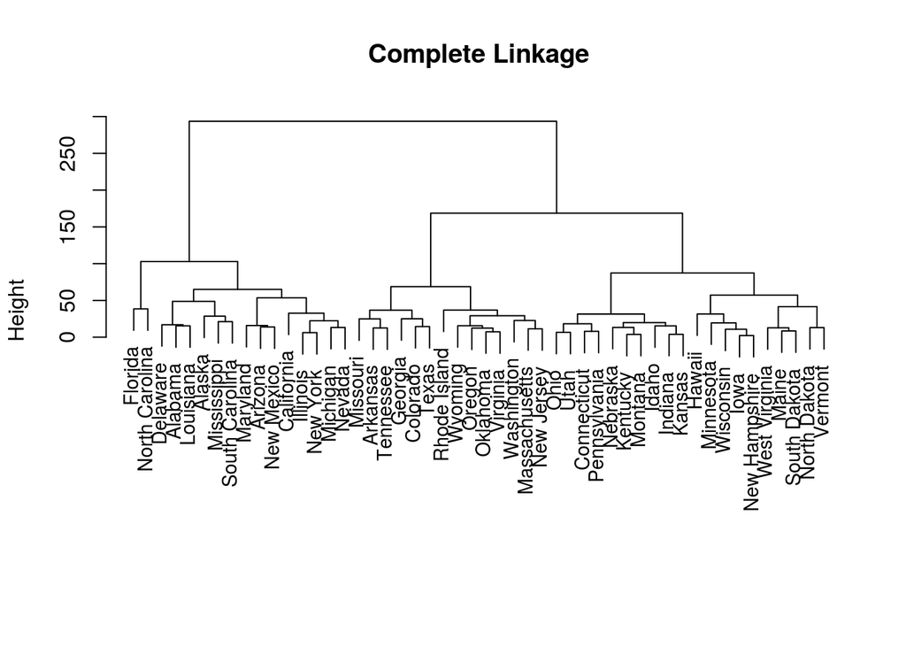

```r
x <- USArrests
hc.complete <- hclust(dist(x), method = "complete")
plot(hc.complete, main = "Complete Linkage", xlab = "", sub = "", cex = .9)
```

### b)

Cut dendrogram at clusters=3

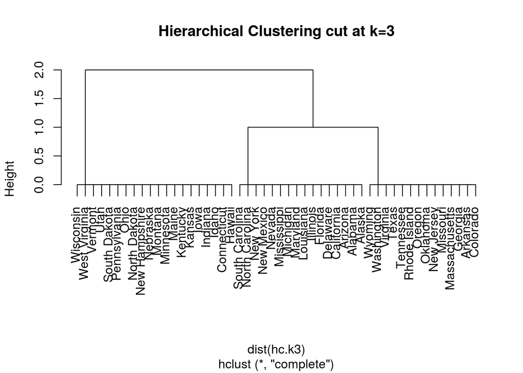

```r
hc.k3 <- cutree(hc.complete, 3)
plot(hclust(dist(hc.k3), method = "complete"), main = "Hierarchical Clustering cut at k=3")
```

### c)

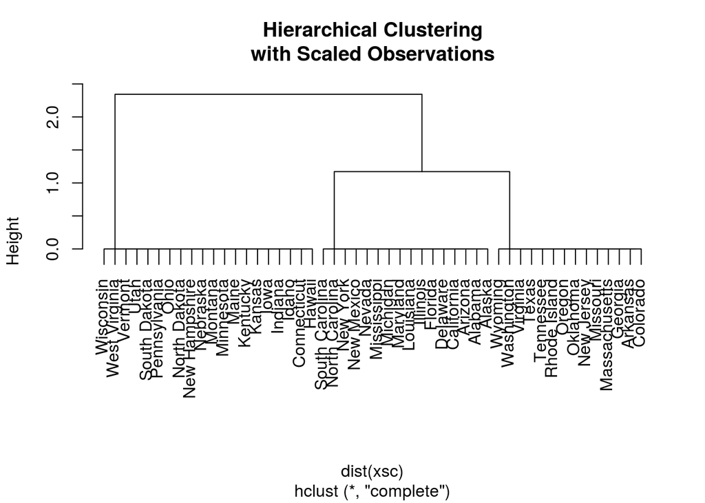

```r
xsc <- scale(hc.k3)
plot(hclust(dist(xsc), method = "complete"), main = "Hierarchical Clustering
with Scaled Observations")
```

### d)

Scaling the dataset makes the variances equal as more weight is not placed on variables with greater values. Variables should be scaled before inter-observation dissimilarities to avoid placing more weight on the variance in variable values. Scaling data also rarely hurts hence it is a good practice in general.